## Title: Digital Threads Through Time: Reimagining Cultural Heritage with AI at the University of Glasgow Archives & Special Collections

# topic selection

#### Introduction

The selected object for the project, is a selection from Galsgow University titled "GB 248 GUA BL/1". It is a historical document of significant importance, encapsulating a pivotal moment in Scottish history. This document, an Inspeximus of a charter dated 21 October 1304, was issued by King Alexander III of Scotland. It signifies a formal entitlement granted by the king to the Black Friars, allowing them an annual income of 10 pounds from the rents of the burgh of Dumbarton.

Objective: The project seeks to engage public interest in heritage by creatively contextualizing the 13th-century Royal Charter of Scotland and resonate with contemporary relevance to governance, law and social order. The main implementation idea is to use artificial intelligence to reproduce the usage scenes of the year, and to use other digital elements to make it more vivid and rich. Interactive content generated using artificial intelligence will engage viewers in conversations questioning the similarities and differences between medieval and current social norms. This approach not only re-examines historical artifacts within the framework of current issues, but also encourages viewers to consider the relevance of ancient charters in shaping the cornerstones of modern democratic and legal systems. People will be actively encouraged to explore the threads that connect past and present.

### 1. display the collection

```python
pip install pillow
```

```python
from PIL import Image
```

```python
img = Image.open('./Image1.jpg')

img.show()
```

```python
###
```

```python
import openai
```

```python
def setup_openai_client(api_key):
    """
    Sets up the OpenAI client with the provided API key.
    """
    openai.api_key = api_key

def generate_text(prompt, max_tokens=100):
    """
    Generates text using GPT-3 based on the given prompt.
    """
    try:
        response = openai.Completion.create(
            engine="text-davinci-003",
            prompt=prompt,
            max_tokens=max_tokens
        )
        return response.choices[0].text.strip()
    except openai.error.OpenAIError as e:
        return f"An error occurred: {e}"

# Example usage:
# setup_openai_client('your-api-key-here')
# historical_context = generate_text("Explain the significance of the Inspeximus charter of King Alexander III in modern terms.")
# print(historical_context)
```

### 2 Recreate historical scene 1:

The Charter's Legacy: A Glimpse into Medieval Scotland

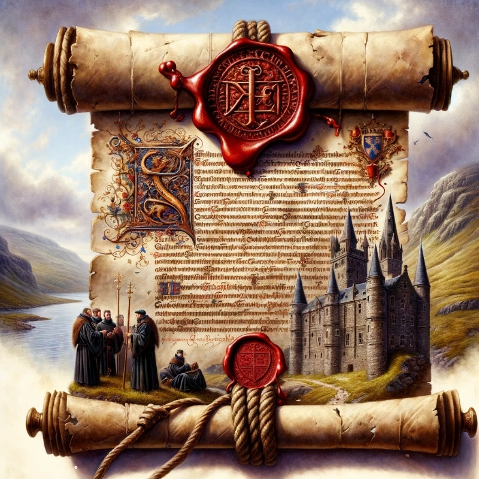

```python
img2 = Image.open('./image2.jpg')

img2
```

### description of the historical scene 1

The image before us whispers tales from the 13th century, a vivid tableau of Scottish heritage. At its heart lies a weathered parchment, the very essence of a royal charter, once held in the hands of the Black Friars. The elegant gothic script that dances across the document tells of a grant by King Alexander III, its importance sealed by the grandeur of an ornate red wax seal. This charter, a conduit of authority and privilege, is framed by the rugged beauty of the Scottish landscape—a castle perched on rolling hillsides, the tranquil flow of the River Clyde in the distance. In the foreground, the Black Friars, draped in their iconic mantles, are caught in a moment of earnest conversation within a monastery garden, their figures a testament to the scholarly and spiritual life of medieval Scotland. Each element of this image, steeped in historical authenticity, brings the cultural and legal significance of the Inspeximus charter to life, bridging centuries to recount a narrative of Scotland's storied past.

### 3. Recreate historical scene 2:

The Exchange: A Moment of Medieval Patronage"

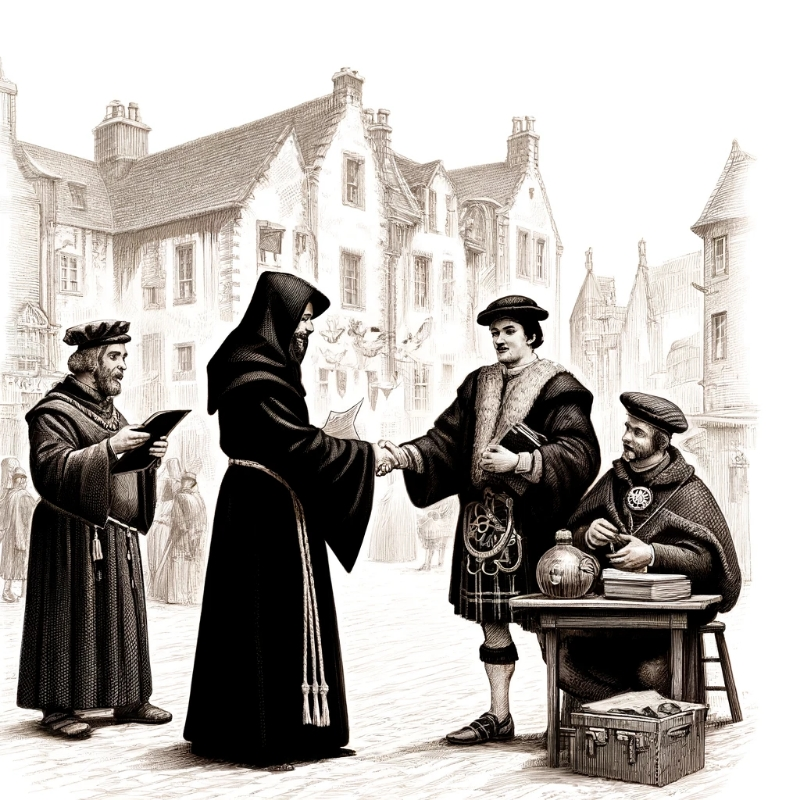

```python
img3 = Image.open('./image3.jpg')

img3
```

Story about its scene: In the heart of Dumbarton, under the watchful gaze of medieval stone structures that line the bustling marketplace, a moment of significant exchange unfolds. A Black Friar, clad in the distinctive dark robes that billow gently in the Scottish breeze, extends a hand to receive 10 pounds—a sum of great importance, authorized by the charter of King Alexander III. Opposite him, a town official, embodying the authority and responsibility of the burgh, presents the money with a sense of reverence and duty. This scene, set against the backdrop of daily life in 1304 Scotland, captures a pivotal interaction. The drawing, with its careful attention to the realistic details of attire and architecture, transports the viewer to a time when such exchanges were foundational to the fabric of society, illustrating the blend of ecclesiastical influence and civic duty that characterized the era.

### 4） In order to learn more about the historical background of this collection, the project used the tool Consensus to conduct a literature search. Then I used python to visualize it and generate a timeline. Interested users or scholars with professional backgrounds can more easily search for relevant literature according to the timeline.

```python
import matplotlib.pyplot as plt
import pandas as pd
```

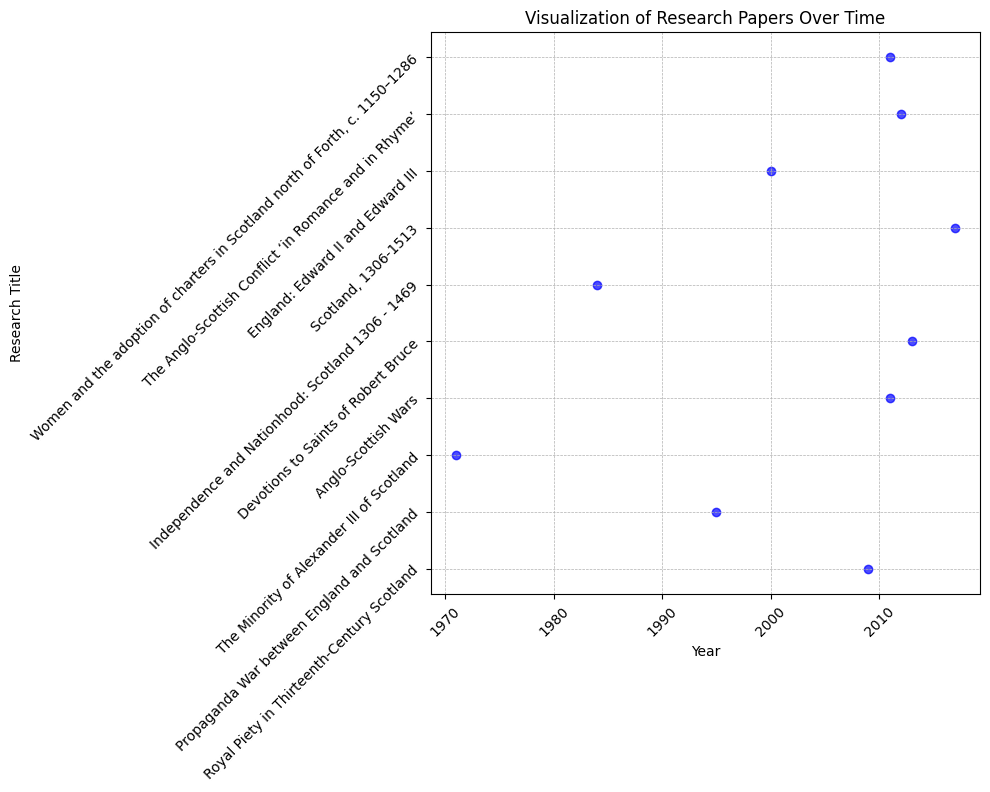

```python
# Data for plotting
data = {
    "Year": [2009, 1995, 1971, 2011, 2013, 1984, 2017, 2000, 2012, 2011],
    "Title": ["Royal Piety in Thirteenth-Century Scotland",
              "Propaganda War between England and Scotland",
              "The Minority of Alexander III of Scotland",
              "Anglo-Scottish Wars",
              "Devotions to Saints of Robert Bruce",
              "Independence and Nationhood: Scotland 1306 - 1469",
              "Scotland, 1306-1513",
              "England: Edward II and Edward III",
              "The Anglo-Scottish Conflict ‘in Romance and in Rhyme’",
              "Women and the adoption of charters in Scotland north of Forth, c. 1150–1286"]
}

df = pd.DataFrame(data)

# Plotting
plt.figure(figsize=(10, 8))
plt.scatter(df["Year"], df["Title"], color='blue', alpha=0.7)
plt.title('Visualization of Research Papers Over Time')
plt.xlabel('Year')
plt.ylabel('Research Title')
plt.xticks(rotation=45)
plt.yticks(rotation=45)
plt.grid(True, which='both', linestyle='--', linewidth=0.5)
plt.tight_layout()

plt.show()
```

#### The chart visualizes the publication years of the research papers related to the historical and religious context of Scotland around the time the charter "GB 248 GUA BL/1" was issued. Each point on the chart represents a research paper, plotted according to its publication year and titled for reference. This visualization provides an overview of the scholarly work done over time, highlighting the enduring interest and continued research into this significant period in Scottish history